# Reproducible Research Case Study

## What Causes PM to be Toxic?

- PM is composed of many different chemical elements
- Some components of PM may be more harmful than others
- Some sources of PM may be more dangerous than others
- Identifying harmful chemical constituents may lead us to strategies for controlling sources of PM

## NMMAPS

- The National Morbidity, Mortality, and Air Pollution Study (NMMAPS) was a national study of the short-term health effects of ambient air pollution
- Focused primarily on particulate matter (\(PM_{10}\)) and ozone (\(O_3\))
- Health outcomes included mortality from all causes and hospitalizations for cardiovascular and respiratory diseases
- Key publications
- http://www.ncbi.nlm.nih.gov/pubmed/11098531
- http://www.ncbi.nlm.nih.gov/pubmed/11354823
- Funded by the [Health Effects Institute](http://www.healtheffects.org)
- Roger Peng currently serves on the Health Effects Institute Health Review Committee

## NMMAPS and Reproducibility

- Data made available at the Internet-based Health and Air Pollution Surveillance System (http://www.ihapss.jhsph.edu)
- Research results and software also available at iHAPSS
- Many studies (over 67 published) have been conducted based on the public data http://www.ncbi.nlm.nih.gov/pubmed/22475833
- Has served as an important test bed for methodological development

## What Causes Particulate Matter to be Toxic?

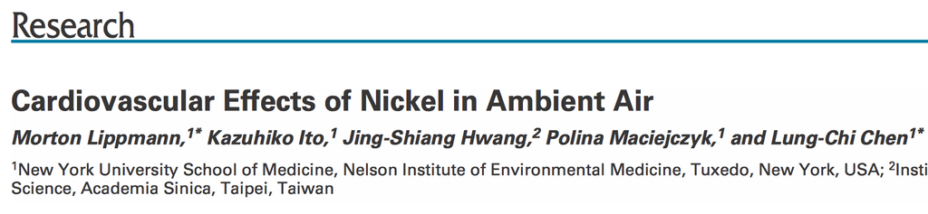

http://www.ncbi.nlm.nih.gov/pmc/articles/PMC1665439/

- Lippmann *et al.* found strong evidence that Ni modified the short-term effect of \(PM_{10}\) across 60 US communities
- No other PM chemical constituent seemed to have the same modifying effect
- To simple to be true?

## A Reanalysis of the Lippmann *et al.* Study

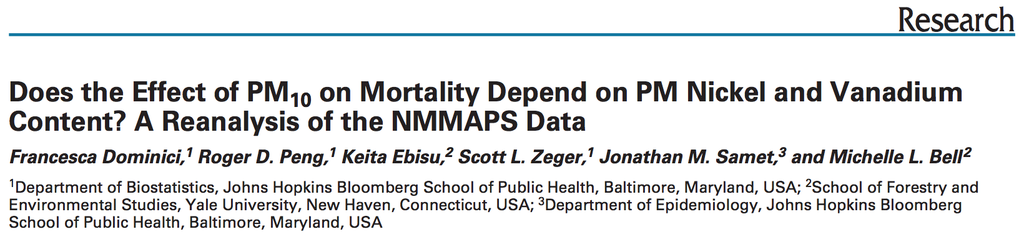

http://www.ncbi.nlm.nih.gov/pmc/articles/PMC2137127/

- Reexamine the data from NMMAPS and link with PM chemical constituent data
- Are the findings sensitive to levels of Nickel in New York City?

## Does Nickel Make PM Toxic?

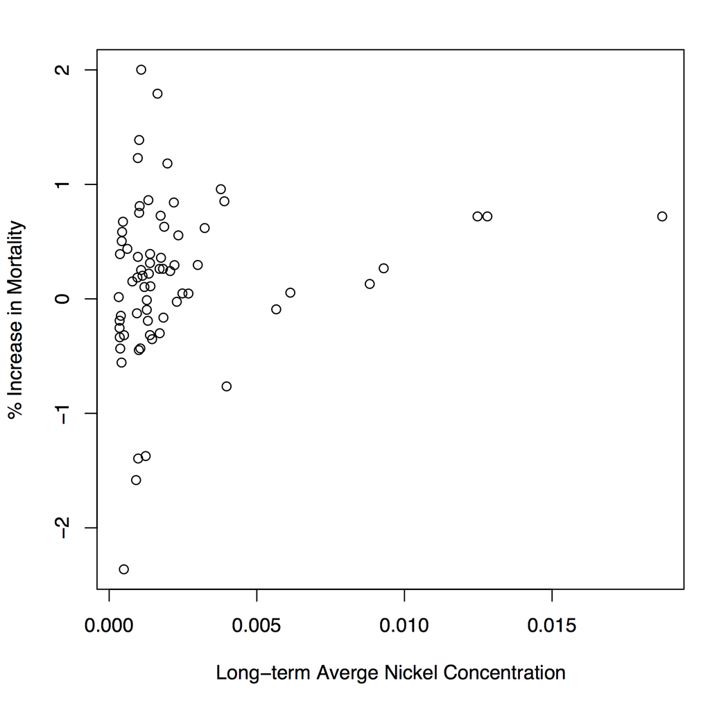

- Long-term average nickel concentrations appear correlated with PM risk
- There appear to be some outliers on the right-hand side (New York City)

## Does Nickel Make PM Toxic?

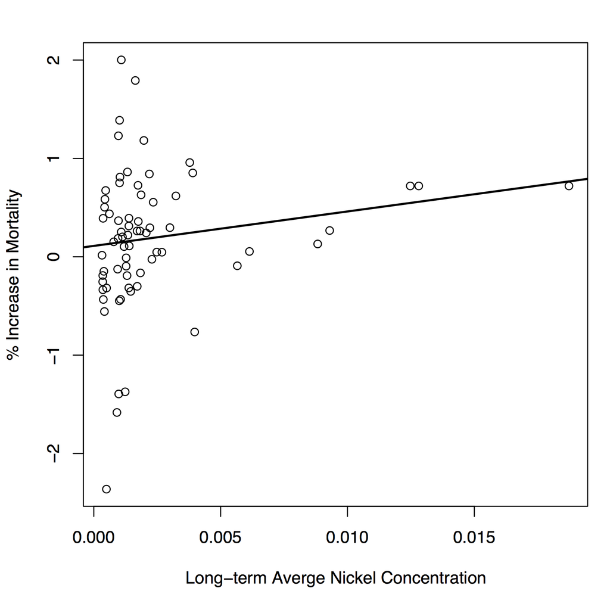

- Regression line statistically significant (\(p < 0.01\))

## Does Nickel Make PM Toxic?

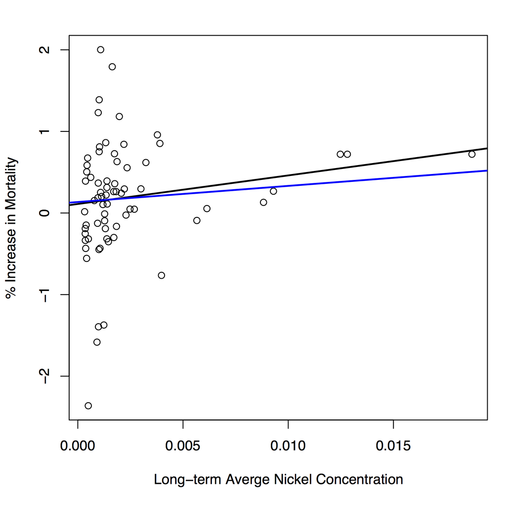

- Adjusted regression line (blue) no longer statistically significant (\(p < 0.31\))

## Does Nickel Make PM Toxic?

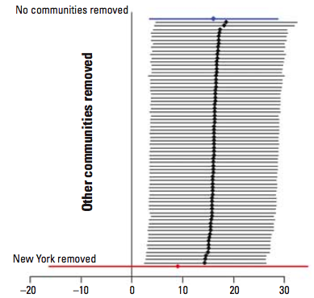

## What Have We Learned?

- New York does have very high levels of nickel and vanadium, much higher than any other US community
- There is evidence of a positive relationship between Ni concentrations and \(PM_{10}\) risk
- The strength of this relationship is highly sensitive to the observations from New York City
- Most of the information in the data is derived from just 3 observations

## Lessons Learned

- Reproducibility of NMMAPS allowed for a secondary analysis (and linking with PM chemical constituent data) investigating a novel hypothesis (Lippmann *et al.*)
- Reproducibility also allowed for a critique of that new analysis and some additional new analysis (Dominici *et al.*)
- Original hypothesis not necessarily invalidated, but evidence not as strong as originally suggested (more work should be done)
- Reproducibility allows for the scientific discussion to occur in a timely and informed manner
- This is how science works